# BST 270 - Reproducible Data Science - Project document

Abhijith Asok

17 October 2017

## Data Pre-processing

### Data Load

First, we read the data in from the system. By default, the missing values in the entire dataset are represented by the “?” symbol. However, to make it easier for R to detect and handle them, they are converted to NAs. The following code does this operation.

```r
diabdata <- read.csv("/Users/abhijithasok/Documents/Harvard Health Data Science/Fall 2017/Reproducible Data Science/Project/Project stuff/diabetic_data.csv", stringsAsFactors = T, header = T, na.strings = c("?","NA"))
```

### Original Data Preservation

In order to preserve the original data so that we could return back to it at a later time for reference if need be, we load it into another variable and use that hereafter, leaving **diabdata** untouched.

```r
diabwork <- diabdata
```

We now start the data pre-processing.

### Missing Values - Column drop

There are 3 variables in the data with a high number of missing values - namely, “weight”, “payer_code” and “medical_specialty”. These can be seen as a percentage of the total number of original rows as follows:

```r
round((colSums(is.na(diabwork))/nrow(diabwork))*100, digits = 2)
```

```
##             encounter_id              patient_nbr                     race
##                     0.00                     0.00                     2.23
##                   gender                      age                   weight
##                     0.00                     0.00                    96.86
##        admission_type_id discharge_disposition_id      admission_source_id
##                     0.00                     0.00                     0.00
##         time_in_hospital               payer_code        medical_specialty
##                     0.00                    39.56                    49.08
##       num_lab_procedures           num_procedures          num_medications
##                     0.00                     0.00                     0.00
##        number_outpatient         number_emergency         number_inpatient
##                     0.00                     0.00                     0.00
##                   diag_1                   diag_2                   diag_3
##                     0.02                     0.35                     1.40
##         number_diagnoses            max_glu_serum                A1Cresult
##                     0.00                     0.00                     0.00
##                metformin              repaglinide              nateglinide
##                     0.00                     0.00                     0.00
##           chlorpropamide              glimepiride            acetohexamide
##                     0.00                     0.00                     0.00
##                glipizide                glyburide              tolbutamide
##                     0.00                     0.00                     0.00
##             pioglitazone            rosiglitazone                 acarbose
##                     0.00                     0.00                     0.00
##                 miglitol             troglitazone               tolazamide
##                     0.00                     0.00                     0.00
##                  examide              citoglipton                  insulin
##                     0.00                     0.00                     0.00
##      glyburide.metformin      glipizide.metformin glimepiride.pioglitazone
##                     0.00                     0.00                     0.00
##  metformin.rosiglitazone   metformin.pioglitazone                   change
##                     0.00                     0.00                     0.00
##              diabetesMed               readmitted
##                     0.00                     0.00
```

We can see here that weight, payer_code and medical_specialty have 96.86%, 39.56% and 49.08% of them as missing values respectively. Since even imputing these values would result in large inaccuracies, we take those variables out of consideration.

```r
diabwork <- diabwork[,!(names(diabwork) %in% c("weight","payer_code","medical_specialty"))]
```

### Missing Values - Row Drop

As we saw in the listing, there are a few other variables with a very low percentage of missing values. Since we have considerable data size, we could just omit those rows that contain missing values in any of the remaining variables.

```r
diabwork <- na.omit(diabwork)
```

### Dependent Variable Re-classification

Our planned dependent variable “readmitted” now contains three levels:

1. “<30”" - Patient readmitted with similar diagnosis within 30 days of leaving the hospital
2. “>30”" - Patient readmitted with similar diagnosis after 30 days of leaving the hospital
3. “NO”" - Patient not readmitted with similar diagnosis again

For simplicity of modelling, we can combine the first two levels into a single level called “YES”, to symbolize the patient being readmitted with a similar diagnosis, irrespective of the timeline. We create a new variable called “readmitted_final” for this purpose and remove the original “readmitted” variable.

```r
diabwork$readmitted_final[diabwork$readmitted %in% c("<30",">30")] <- "YES"
diabwork$readmitted_final[diabwork$readmitted == "NO"] <- "NO"
diabwork <- diabwork[,!names(diabwork) == "readmitted"]
```

### Assigning the right datatypes

A deeper look into the dataset reveals that the dataset consists of integer and factor variables only.

```r
str(diabwork)
```

```
## 'data.frame':    98053 obs. of  47 variables:
##  $ encounter_id            : int  149190 64410 500364 16680 35754 55842 63768 12522 15738 28236 ...
##  $ patient_nbr             : int  55629189 86047875 82442376 42519267 82637451 84259809 114882984 48330783 63555939 89869032 ...
##  $ race                    : Factor w/ 5 levels "AfricanAmerican",..: 3 1 3 3 3 3 3 3 3 1 ...
##  $ gender                  : Factor w/ 3 levels "Female","Male",..: 1 1 2 2 2 2 2 1 1 1 ...
##  $ age                     : Factor w/ 10 levels "[0-10)","[10-20)",..: 2 3 4 5 6 7 8 9 10 5 ...
##  $ admission_type_id       : int  1 1 1 1 2 3 1 2 3 1 ...
##  $ discharge_disposition_id: int  1 1 1 1 1 1 1 1 3 1 ...
##  $ admission_source_id     : int  7 7 7 7 2 2 7 4 4 7 ...
##  $ time_in_hospital        : int  3 2 2 1 3 4 5 13 12 9 ...
##  $ num_lab_procedures      : int  59 11 44 51 31 70 73 68 33 47 ...
##  $ num_procedures          : int  0 5 1 0 6 1 0 2 3 2 ...
##  $ num_medications         : int  18 13 16 8 16 21 12 28 18 17 ...
##  $ number_outpatient       : int  0 2 0 0 0 0 0 0 0 0 ...
##  $ number_emergency        : int  0 0 0 0 0 0 0 0 0 0 ...
```

[output cut: 33 more lines]

However, some variables that are originally meant to be factor(since they are ID variables or equivalent) have been wrongly categorized as integer or character. These are:

1. encounter_id
2. patient_nbr
3. admission_type_id
4. discharge_disposition_id
5. admission_source_id
6. readmitted_final

We convert these into factors and check the conversion to confirm.

```r
diabwork[,c(1,2,6,7,8,47)] <- lapply(diabwork[,c(1,2,6,7,8,47)],factor)
str(diabwork)
```

```
## 'data.frame':    98053 obs. of  47 variables:
##  $ encounter_id            : Factor w/ 98053 levels "12522","15738",..: 17 12 44 3 5 9 11 1 2 4 ...
##  $ patient_nbr             : Factor w/ 68630 levels "135","378","729",..: 36225 50089 47412 30448 47479 48067 65681 33892 40562 52835 ...
##  $ race                    : Factor w/ 5 levels "AfricanAmerican",..: 3 1 3 3 3 3 3 3 3 1 ...
##  $ gender                  : Factor w/ 3 levels "Female","Male",..: 1 1 2 2 2 2 2 1 1 1 ...
##  $ age                     : Factor w/ 10 levels "[0-10)","[10-20)",..: 2 3 4 5 6 7 8 9 10 5 ...
##  $ admission_type_id       : Factor w/ 8 levels "1","2","3","4",..: 1 1 1 1 2 3 1 2 3 1 ...
##  $ discharge_disposition_id: Factor w/ 26 levels "1","2","3","4",..: 1 1 1 1 1 1 1 1 3 1 ...
##  $ admission_source_id     : Factor w/ 17 levels "1","2","3","4",..: 7 7 7 7 2 2 7 4 4 7 ...
##  $ time_in_hospital        : int  3 2 2 1 3 4 5 13 12 9 ...
##  $ num_lab_procedures      : int  59 11 44 51 31 70 73 68 33 47 ...
##  $ num_procedures          : int  0 5 1 0 6 1 0 2 3 2 ...
##  $ num_medications         : int  18 13 16 8 16 21 12 28 18 17 ...
##  $ number_outpatient       : int  0 2 0 0 0 0 0 0 0 0 ...
##  $ number_emergency        : int  0 0 0 0 0 0 0 0 0 0 ...
```

[output cut: 33 more lines]

### Dataset sampling

Since the dataset is too large and would take time to run, we make a subset of the entire dataset to work with. We can pick out 2000 rows from the dataset through a random sample. However, we go for stratified random sampling based on the dependent “readmitted_final” variable to ensure equal representation of both levels of the variable. We use the “sample_n” function from the ‘dplyr’ package for this.

```r
library(dplyr)
set.seed(123)
diaboverall <- diabwork %>% group_by(readmitted_final) %>% sample_n(1000)
```

### Omitting uninformative variables

Since ‘examide’ and ‘citoglipton’ are both factors with just 1 level, they are of no use to us. Hence, we remove them.

```r
diaboverall <- diaboverall %>% select(-examide,-citoglipton)
```

### Train-Test Split

Now we split it into train and test datasets based on a direct 70 - 30 split for convenience.

```r
indices <- sample(1:nrow(diaboverall), size=0.7*nrow(diaboverall))
diabtrain <- diaboverall[indices,]
diabtest <- diaboverall[-indices,]
```

### Reassigning the dependent variable

Let’s convert the “readmitted_final” column into 0 and 1.

```r
diabtrain$readmitted_final_model <- ""
diabtest$readmitted_final_model <- ""
diabtrain$readmitted_final_model[diabtrain$readmitted_final == "YES"] <- 1
diabtrain$readmitted_final_model[diabtrain$readmitted_final == "NO"] <- 0
diabtrain$readmitted_final_model <- as.factor(diabtrain$readmitted_final_model)
diabtest$readmitted_final_model[diabtest$readmitted_final == "YES"] <- 1
diabtest$readmitted_final_model[diabtest$readmitted_final == "NO"] <- 0
diabtest$readmitted_final_model <- as.factor(diabtest$readmitted_final_model)
diabtrain$readmitted_final <- NULL
diabtest$readmitted_final <- NULL
```

These are the final datasets that we would be using. We’ll keep the test set aside for now and move to some basic exploratory data analysis on the training set.

## Exploratory Data Analysis

### Integer - Factor separation

For this, we first separate out the integer and the factor variables so that we can look at both differently.

```r
ints <- sapply(diabtrain, is.integer)
diabtrain_int <- diabtrain[,ints]
diabtrain_factor <- diabtrain[,!ints]
```

### Scatterplot Matrix

Let’s create a scatter plot matrix of the integer variables and analyze correlations between them. We’ll use the ‘ggpairs’ command in the ‘GGally’ package for this.

```r
library(GGally)
```

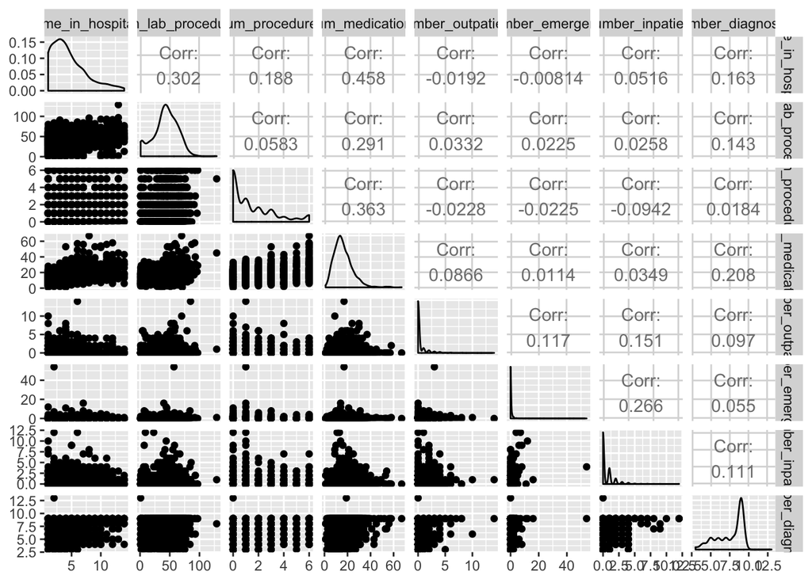

```r
ggpairs(diabtrain_int)
```

We can see that there is no correlation that can be considered to be high.

### Correlation Plot

To visualize the correlation better, let’s make a correlation plot

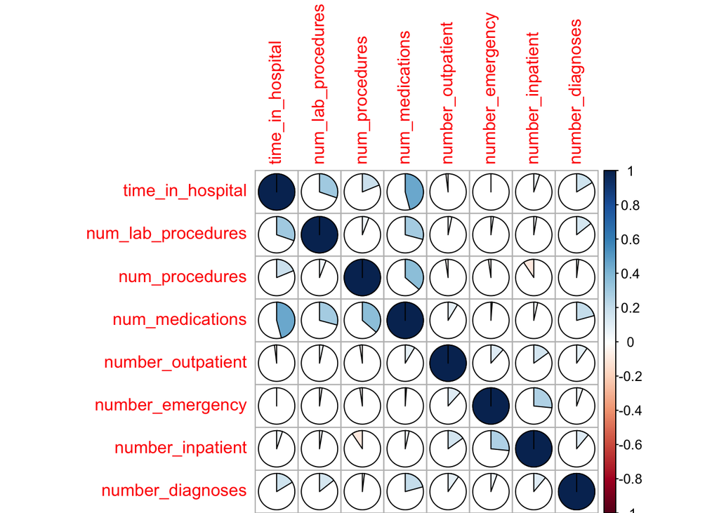

```r
library(corrplot)
corrplot(cor(diabtrain_int), method = "pie")
```

The plot makes the lack of high correlation evident. Therefore, we ignore any variable elimination for now.

### Race, Gender, Age distribution

Let’s look at the distribution of the people who were admitted across their race, gender and age bracket, in the data

```r
diabtrain %>% group_by(race) %>% summarise(no_rows = length(race))
```

```
## # A tibble: 5 x 2
##              race no_rows
##            <fctr>   <int>
## 1 AfricanAmerican     264
## 2           Asian       7
## 3       Caucasian    1073
## 4        Hispanic      30
## 5           Other      26
```

```r
diabtrain %>% group_by(gender) %>% summarise(no_rows = length(gender))
```

```
## # A tibble: 2 x 2
##   gender no_rows
##   <fctr>   <int>
## 1 Female     759
## 2   Male     641
```

```r
diabtrain %>% group_by(age) %>% summarise(no_rows = length(age))
```

```
## # A tibble: 10 x 2
##         age no_rows
##      <fctr>   <int>
##  1   [0-10)       1
##  2  [10-20)       6
##  3  [20-30)      16
##  4  [30-40)      37
##  5  [40-50)     129
##  6  [50-60)     239
##  7  [60-70)     308
##  8  [70-80)     366
##  9  [80-90)     259
## 10 [90-100)      39
```

Let’s visualize these using ‘ggplot’ for better understanding.

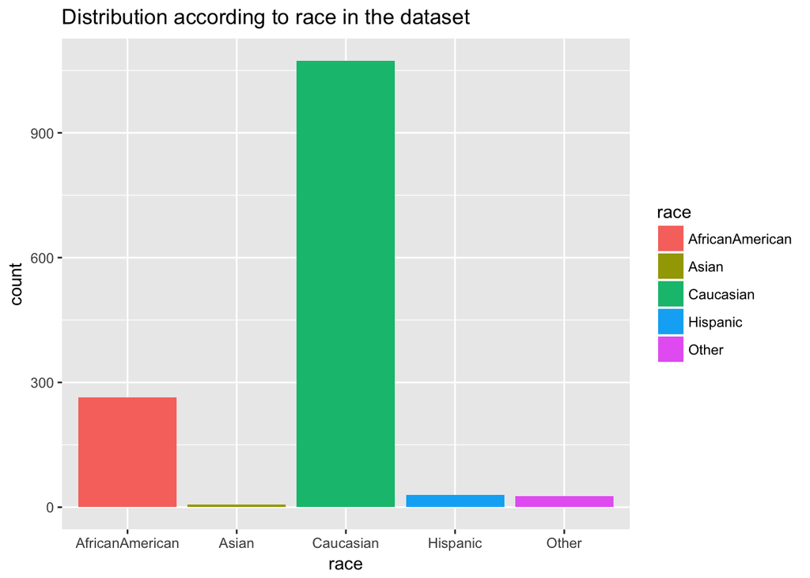

```r
library(ggplot2)
diabtrain %>% ggplot(aes(x=race, fill=race)) + geom_bar() + ggtitle("Distribution according to race in the dataset")
```

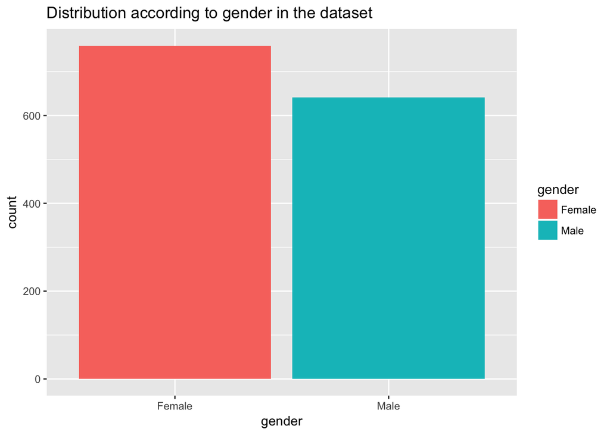

```r
diabtrain %>% ggplot(aes(x=gender, fill=gender)) + geom_bar() + ggtitle("Distribution according to gender in the dataset")
```

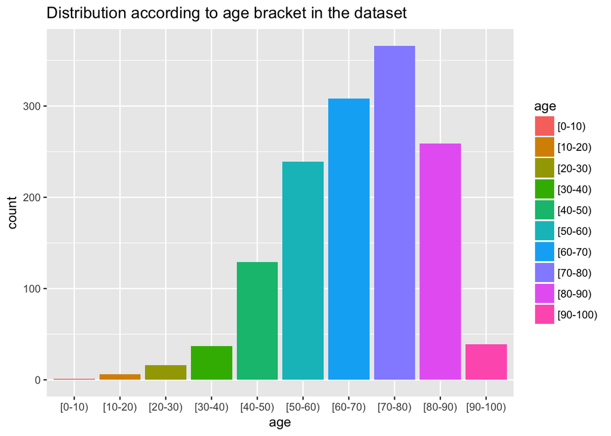

```r
diabtrain %>% ggplot(aes(x=age, fill=age)) + geom_bar() + ggtitle("Distribution according to age bracket in the dataset")
```

**Although the gender distribution is approximately balanced, there is a huge imbalance in the race of people admitted for diabetes. The Caucasian race has way more admitted patients for diabetes than any other race. The age bracket distribution is also skewed and resembles a left-skewed normal distribution with the mean around the (70-80) age bracket.**

### Time spent in hospital across race, gender, age

Let’s look at the time spent in hospital distributed over race, gender and age.

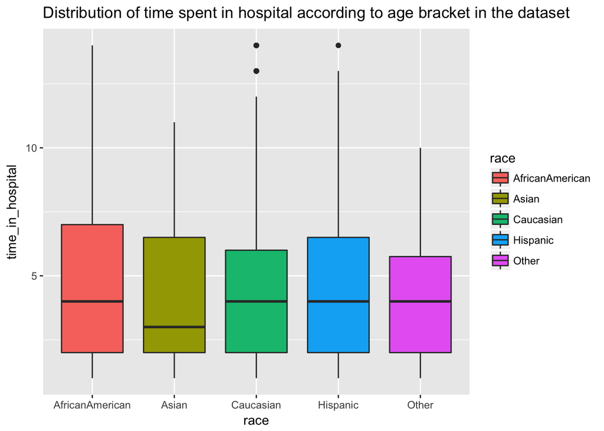

```r
diabtrain %>% ggplot(aes(x=race, y=time_in_hospital,fill=race)) + geom_boxplot() + ggtitle("Distribution of time spent in hospital according to age bracket in the dataset")
```

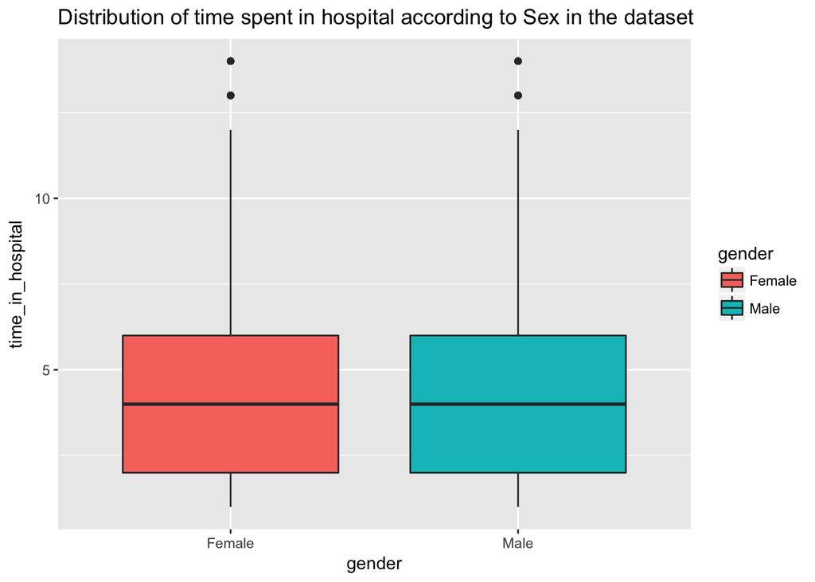

```r
diabtrain %>% ggplot(aes(x=gender, y=time_in_hospital,fill=gender)) + geom_boxplot() + ggtitle("Distribution of time spent in hospital according to Sex in the dataset")
```

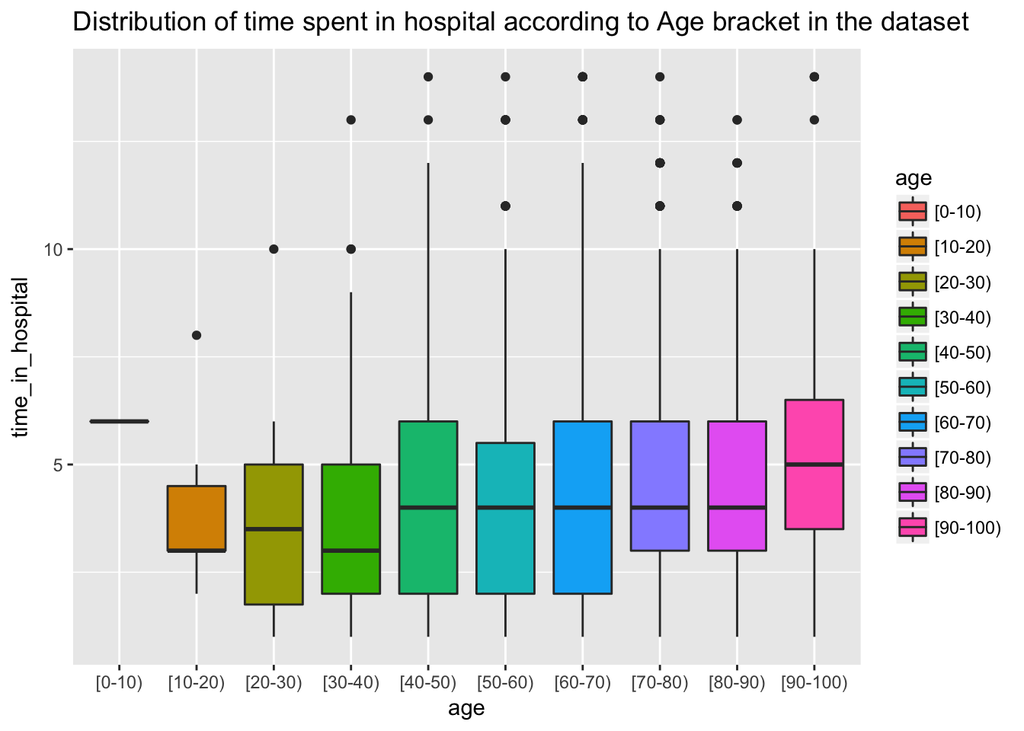

```r
diabtrain %>% ggplot(aes(x=age, y=time_in_hospital,fill=age)) + geom_boxplot() + ggtitle("Distribution of time spent in hospital according to Age bracket in the dataset")
```

## Modelling

### Tree Modelling

```r
library(rpart)
set.seed(123)
model_tree <- rpart(readmitted_final_model~., data = subset(diabtrain, select = -c(diag_1,diag_2,diag_3,encounter_id,patient_nbr)))
predict_tree <- data.frame(predict(model_tree,newdata = diabtest[,-45],type = "class"))
Prec_tree <- data.frame("Expected" = diabtest$readmitted_final_model, "Observed" = predict_tree[,1])
Prec_tree$Equal <- as.numeric("")
Prec_tree$Equal[Prec_tree$Expected == Prec_tree$Observed] <- 1
Prec_tree$Equal[Prec_tree$Expected != Prec_tree$Observed] <- 0
Accuracy <- (length(Prec_tree$Equal[Prec_tree$Equal == 1])/nrow(diabtest))*100
Accuracy
```

```
## [1] 60.66667
```

This is a fairly accurate prediction for a dataset that is well-balanced. Let’s visualise this tree

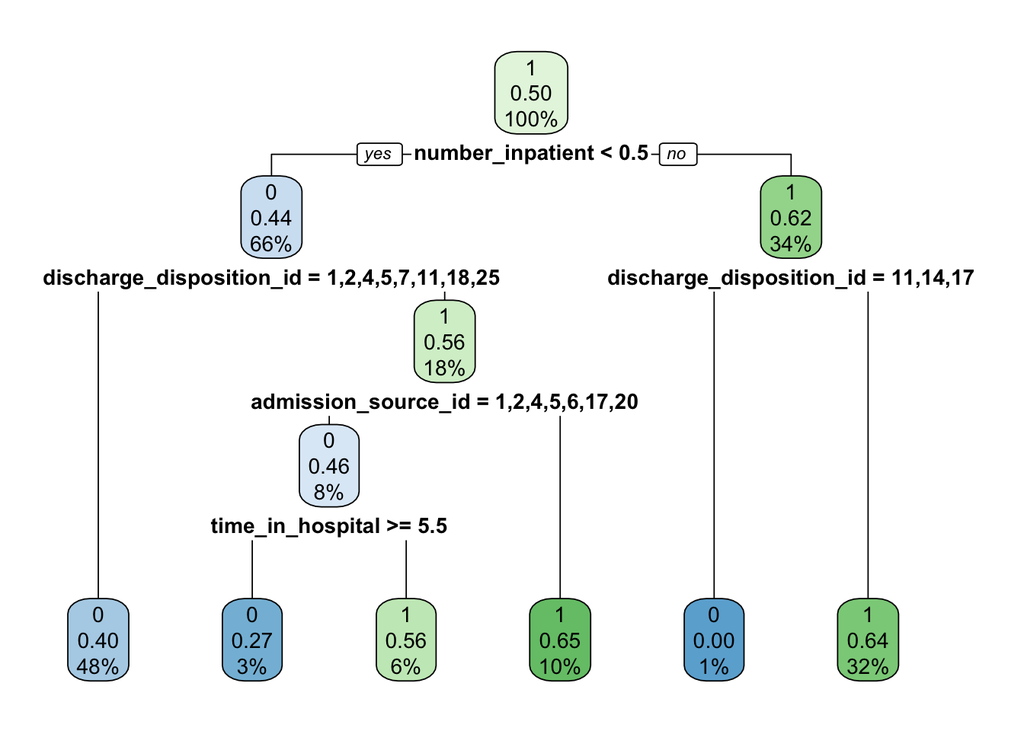

```r
library(rpart.plot)
rpart.plot(model_tree)
```

We see from the tree that the variables in most use are `number_inpatient, discharge_disposition_id, admission_source_id,time_in_hospital`.

Let’s look at the variable importance in this tree in further detail.

```r
model_tree$variable.importance
```

```
## discharge_disposition_id         number_inpatient         time_in_hospital
##               21.6423975               19.9880655                5.6363988
##      admission_source_id        admission_type_id       num_lab_procedures
##                5.4418896                2.8679710                1.9190793
##         number_emergency          num_medications         number_diagnoses
##                1.2785543                1.2283497                1.1089488
##           num_procedures                      age        number_outpatient
##                1.0323941                0.9320485                0.4688032
##                  insulin            max_glu_serum
##                0.4588418                0.1278554
```

These 14 variables seem to be what the tree used and seem to be the set of most important variables.

Let’s make this more accurate using Random Forests.

### Random Forest

First, we make a random forest using all variables excluding ID variables and the diags(since they are factor variables with too many levels as compared to the dataset size which make them difficult to handle.) This is our base model.

```r
library(randomForest)
set.seed(123)

model_forest <- randomForest(readmitted_final_model~., data = subset(diabtrain, select =  -c(diag_1,diag_2,diag_3,encounter_id,patient_nbr)), ntree = 100, replace = TRUE)

predict_forest <- data.frame(predict(model_forest,newdata = diabtest[,-45],type = "class"))

Prec_forest <- data.frame("Expected" = diabtest$readmitted_final_model, "Observed" = predict_forest[,1])

Prec_forest$Equal <- as.numeric("")
Prec_forest$Equal[Prec_forest$Expected == Prec_forest$Observed] <- 1
Prec_forest$Equal[Prec_forest$Expected != Prec_forest$Observed] <- 0

Accuracy <- (length(Prec_forest$Equal[Prec_forest$Equal == 1])/nrow(diabtest))*100
paste("Prediction accuracy:",round(Accuracy,digits = 2),"%")
```

```
## [1] "Prediction accuracy: 63.33 %"
```

```r
#Metrics
predict_forest <- data.frame(predictions = predict(model_forest,newdata = diabtest[,-45],type = "prob"))

predict_forest$pred <- ifelse(predict_forest$predictions.0 > predict_forest$predictions.1, predict_forest$predictions.0,predict_forest$predictions.1)

brier_score <- mean((as.numeric(predict_forest$pred) - as.numeric(Prec_forest$Expected)))^2
paste("Brier Score:",round(brier_score,digits = 4))
```

```
## [1] "Brier Score: 0.7603"
```

```r
library(pROC)
roc_pred <- roc(Prec_forest$Expected,predict_forest$pred)
roc_pred$auc
```

```
## Area under the curve: 0.5145
```

Our accuracy is just over 63%. However, our Brier Score is really undesirable at 0.76 with an unimpressive AUC

Now we use just the 4 variables that were depicted in the tree visualisation.

```r
library(randomForest)
set.seed(123)

model_forest <- randomForest(readmitted_final_model~., data = subset(diabtrain, select = c(number_inpatient,discharge_disposition_id,admission_source_id,time_in_hospital,readmitted_final_model)), ntree = 100, replace = TRUE)

predict_forest <- data.frame(predict(model_forest,newdata = diabtest[,-45],type = "class"))

Prec_forest <- data.frame("Expected" = diabtest$readmitted_final_model, "Observed" = predict_forest[,1])

Prec_forest$Equal <- as.numeric("")
Prec_forest$Equal[Prec_forest$Expected == Prec_forest$Observed] <- 1
Prec_forest$Equal[Prec_forest$Expected != Prec_forest$Observed] <- 0

Accuracy <- (length(Prec_forest$Equal[Prec_forest$Equal == 1])/nrow(diabtest))*100
paste("Prediction accuracy:",round(Accuracy,digits = 2),"%")
```

```
## [1] "Prediction accuracy: 58.83 %"
```

```r
#Metrics
predict_forest <- data.frame(predictions = predict(model_forest,newdata = diabtest[,-45],type = "prob"))

predict_forest$pred <- ifelse(predict_forest$predictions.0 > predict_forest$predictions.1, predict_forest$predictions.0,predict_forest$predictions.1)

brier_score <- mean((as.numeric(predict_forest$pred) - as.numeric(Prec_forest$Expected)))^2
paste("Brier Score:",round(brier_score,digits = 4))
```

```
## [1] "Brier Score: 0.4851"
```

```r
library(pROC)
roc_pred <- roc(Prec_forest$Expected,predict_forest$pred)
roc_pred$auc
```

```
## Area under the curve: 0.5475
```

This gives us almost 59% accuracy. Adding almost 40 more variables hence give us just 4% more accuracy for a very high computational cost. This model also witnesses a sharp drop in Brier Score at 0.48, which, although not a desirable value, is much better than the base model. The AUC here is higher than the base model as well.

Now, let’s create a random forest with the 14 variables that were used in the tree.

```r
library(randomForest)
set.seed(123)

model_forest <- randomForest(readmitted_final_model~., data = subset(diabtrain, select = c(discharge_disposition_id,number_inpatient,time_in_hospital,admission_source_id,admission_type_id,num_lab_procedures,number_emergency,num_medications,number_diagnoses,num_procedures,age,number_outpatient,insulin,max_glu_serum,readmitted_final_model), ntree = 100, replace = TRUE))

predict_forest <- data.frame(predict(model_forest,newdata = diabtest[,-45],type = "class"))

Prec_forest <- data.frame("Expected" = diabtest$readmitted_final_model, "Observed" = predict_forest[,1])

Prec_forest$Equal <- as.numeric("")
Prec_forest$Equal[Prec_forest$Expected == Prec_forest$Observed] <- 1
Prec_forest$Equal[Prec_forest$Expected != Prec_forest$Observed] <- 0

Accuracy <- (length(Prec_forest$Equal[Prec_forest$Equal == 1])/nrow(diabtest))*100
paste("Prediction accuracy:",round(Accuracy,digits = 2),"%")
```

```
## [1] "Prediction accuracy: 60.67 %"
```

```r
#Metrics
predict_forest <- data.frame(predictions = predict(model_forest,newdata = diabtest[,-45],type = "prob"))

predict_forest$pred <- ifelse(predict_forest$predictions.0 > predict_forest$predictions.1, predict_forest$predictions.0,predict_forest$predictions.1)

brier_score <- mean((as.numeric(predict_forest$pred) - as.numeric(Prec_forest$Expected)))^2
paste("Brier Score:",round(brier_score,digits = 4))
```

```
## [1] "Brier Score: 0.7443"
```

```r
library(pROC)
roc_pred <- roc(Prec_forest$Expected,predict_forest$pred)
roc_pred$auc
```

```
## Area under the curve: 0.5174
```

Addition of 10 variables jumped us up 1%. But, our Brier score is back high and the AUC is back to what it was in the base model.

The better model of choice here would be the simple model with 4 variables.

As a comparison, let’s model this data using Support Vector Machines to see how they fair against tree-based models.

### SVM

```r
library(e1071)
set.seed(123)

model_svm <- svm(readmitted_final_model~., data = subset(diabtrain, select = -c(diag_1,diag_2,diag_3,encounter_id,patient_nbr)))

predict_svm <- data.frame(predict(model_svm,newdata = diabtest[,-45],type = "class"))

Prec_svm <- data.frame("Expected" = diabtest$readmitted_final_model, "Observed" = predict_svm[,1])

Prec_svm$Equal <- as.numeric("")
Prec_svm$Equal[Prec_svm$Expected == Prec_svm$Observed] <- 1
Prec_svm$Equal[Prec_svm$Expected != Prec_svm$Observed] <- 0

Accuracy <- (length(Prec_svm$Equal[Prec_svm$Equal == 1])/nrow(diabtest))*100
Accuracy
```

```
## [1] 61.5
```

Our accuracy is 61.5%. Now we use just the 4 variables that were depicted in the tree visualisation.

```r
library(e1071)
set.seed(123)
model_svm <- svm(readmitted_final_model~., data = subset(diabtrain, select = c(number_inpatient,discharge_disposition_id,admission_source_id,time_in_hospital,readmitted_final_model)))
predict_svm <- data.frame(predict(model_svm,newdata = diabtest[,-45],type = "class"))
Prec_svm <- data.frame("Expected" = diabtest$readmitted_final_model, "Observed" = predict_svm[,1])
Prec_svm$Equal <- as.numeric("")
Prec_svm$Equal[Prec_svm$Expected == Prec_svm$Observed] <- 1
Prec_svm$Equal[Prec_svm$Expected != Prec_svm$Observed] <- 0
Accuracy <- (length(Prec_svm$Equal[Prec_svm$Equal == 1])/nrow(diabtest))*100
Accuracy
```

```
## [1] 57.83333
```

This gives us almost 58% accuracy. Adding almost 40 more variables hence give us just 3.5% more accuracy for a very high computational cost.

Now, let’s create an svm with the 14 variables that were used in the tree.

```r
library(e1071)
set.seed(123)
model_svm <- svm(readmitted_final_model~., data = subset(diabtrain, select = c(discharge_disposition_id,number_inpatient,time_in_hospital,admission_source_id,admission_type_id,num_lab_procedures,number_emergency,num_medications,number_diagnoses,num_procedures,age,number_outpatient,insulin,max_glu_serum,readmitted_final_model), ntree = 100, replace = TRUE))
predict_svm <- data.frame(predict(model_svm,newdata = diabtest[,-45],type = "class"))
Prec_svm <- data.frame("Expected" = diabtest$readmitted_final_model, "Observed" = predict_svm[,1])
Prec_svm$Equal <- as.numeric("")
Prec_svm$Equal[Prec_svm$Expected == Prec_svm$Observed] <- 1
Prec_svm$Equal[Prec_svm$Expected != Prec_svm$Observed] <- 0
Accuracy <- (length(Prec_svm$Equal[Prec_svm$Equal == 1])/nrow(diabtest))*100
Accuracy
```

```
## [1] 61.66667
```

We see that in this case, a simpler model achieves marginally higher accuracy than the model involving almost all the variables.